# Most Streamed Spotify Songs

Which elements contribute most to song popularity?

Author

Affiliation

Ciara Trigg

University of Scranton

## Background

[The data used in this project](https://www.kaggle.com/datasets/nelgiriyewithana/top-spotify-songs-2023) was originally sourced by Kaggle user [Nidula Elgiriyewithana](https://www.kaggle.com/nelgiriyewithana) from the [Spotify API](https://developer.spotify.com/documentation/web-api/reference/get-multiple-artists). The Spotify API is provided by Spotify as a tool for developers to access and interact with their music library. This specific data set provides insights into each song’s popularity and various audio features. Although this data set does contain streaming statistics for Apple Music, Deezer, and Shazam as well, this project will focus on the streaming data from Spotify only.

### Initial Research Question

We would like to know which audio features, if any, impact the amount of streams a song may receive. Different song qualities make them more of less appropriate for certain occasions, but, in a general sense, do the qualities of a song affect the number of streams it will receive overall? Further, we will examine whether or not a song will be in the top 10 based on the artists’ name.

## Data Collection and Documentation

The data was downloaded from Kaggle in the form of a csv file, and read using the `read.csv` function in R. For further exploration, the Spotify API, where this data was sourced from, can be accessed [here](https://developer.spotify.com/documentation/web-api/reference/get-multiple-artists).

```r
# Load the data
music_df <- read.csv("../semester_project_trigg/data/spotify-2023.csv")

# Omit missing values, scale streams
music_df <- music_df[!(music_df$key == ""), ]
music_df <- music_df[!(music_df$in_shazam_charts == ""), ]
music_df <- music_df %>% mutate(streams = log10(as.numeric(streams)))
music_df <- na.omit(music_df)

music_df %>% head(5) %>%
  kable()
```

| track_name | artist.s._name | artist_count | released_year | released_month | released_day | in_spotify_playlists | in_spotify_charts | streams | in_apple_playlists | in_apple_charts | in_deezer_playlists | in_deezer_charts | in_shazam_charts | bpm | key | mode | danceability_. | valence_. | energy_. | acousticness_. | instrumentalness_. | liveness_. | speechiness_. |
| --- | --- | --- | --- | --- | --- | --- | --- | --- | --- | --- | --- | --- | --- | --- | --- | --- | --- | --- | --- | --- | --- | --- | --- |
| Seven (feat. Latto) (Explicit Ver.) | Latto, Jung Kook | 2 | 2023 | 7 | 14 | 553 | 147 | 8.150393 | 43 | 263 | 45 | 10 | 826 | 125 | B | Major | 80 | 89 | 83 | 31 | 0 | 8 | 4 |
| LALA | Myke Towers | 1 | 2023 | 3 | 23 | 1474 | 48 | 8.126184 | 48 | 126 | 58 | 14 | 382 | 92 | C# | Major | 71 | 61 | 74 | 7 | 0 | 10 | 4 |
| vampire | Olivia Rodrigo | 1 | 2023 | 6 | 30 | 1397 | 113 | 8.146140 | 94 | 207 | 91 | 14 | 949 | 138 | F | Major | 51 | 32 | 53 | 17 | 0 | 31 | 6 |
| Cruel Summer | Taylor Swift | 1 | 2019 | 8 | 23 | 7858 | 100 | 8.903546 | 116 | 207 | 125 | 12 | 548 | 170 | A | Major | 55 | 58 | 72 | 11 | 0 | 11 | 15 |
| WHERE SHE GOES | Bad Bunny | 1 | 2023 | 5 | 18 | 3133 | 50 | 8.481781 | 84 | 133 | 87 | 15 | 425 | 144 | A | Minor | 65 | 23 | 80 | 14 | 63 | 11 | 6 |

## Exploratory Analysis and Observations

### Variable Relationships

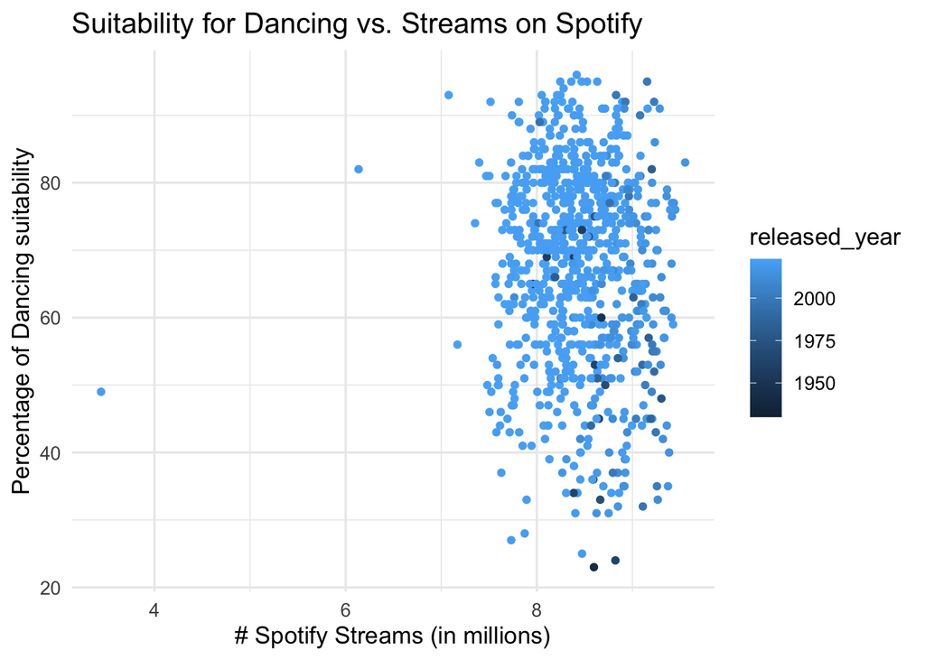

```r
music_df %>%
  ggplot(aes(x=streams, y=danceability_., color=released_year)) +
  geom_point() +
  ggtitle("Suitability for Dancing vs. Streams on Spotify") +
  labs(x = "# Spotify Streams (in millions)", y="Percentage of Dancing suitability")
```

From this graph, there appears to be little correlation between a song’s suitability for dancing and the number of streams it receives. Initially, I assumed that the most danceable songs would have the highest number of streams, but upon revaluation I think the lack of correlation is appropriate. This is because danceable music is not appropriate for all situations and therefore it does not seem necessary that the two variables would be directly related.

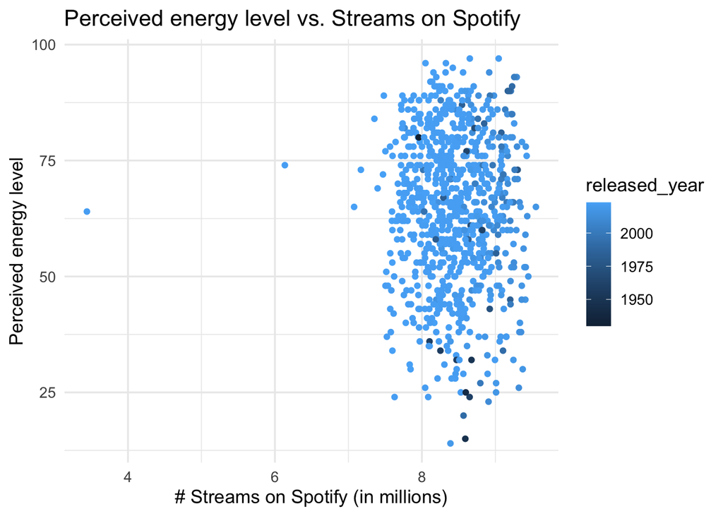

```r
music_df %>%
  ggplot(aes(x=streams, y=energy_., color=released_year)) +
  geom_point() +
  ggtitle("Perceived energy level vs. Streams on Spotify") +
  labs(x = "# Streams on Spotify (in millions)", y="Perceived energy level")
```

Similarly, there is not a distinct trend between energy level of a song and the number of streams it receives.

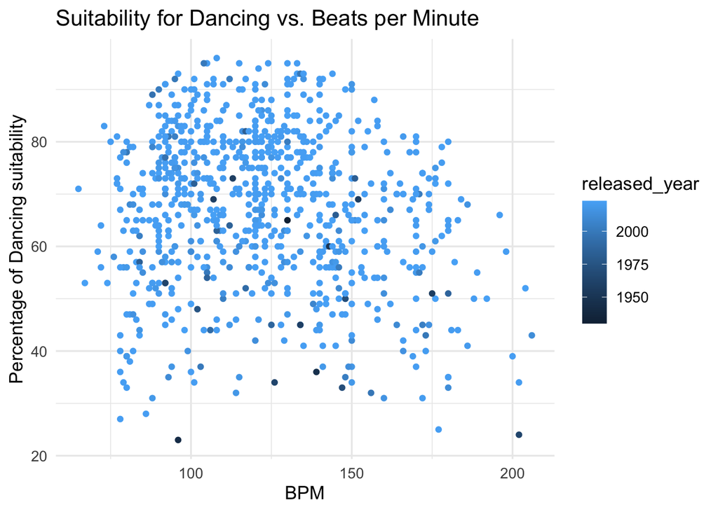

```r
music_df %>%
  ggplot(aes(x=bpm, y=danceability_., color=released_year)) +
  geom_point() +
  ggtitle("Suitability for Dancing vs. Beats per Minute") +
  labs(x = "BPM", y="Percentage of Dancing suitability")
```

The percentage of dancing suitability peaks for songs between 100-150 BPM. Outside of this range, especially after 150 BPM, the danceability drops off steeply going as low as ~25%.

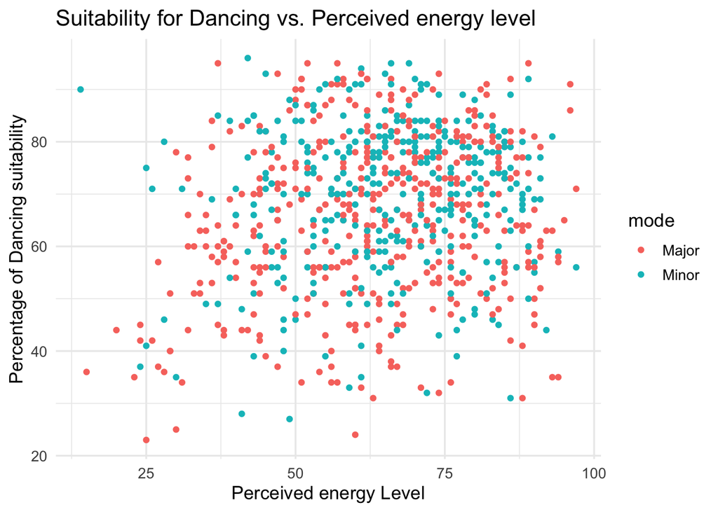

```r
music_df %>%
  ggplot(aes(x=energy_., y=danceability_., color=mode)) +
  geom_point() +
  ggtitle("Suitability for Dancing vs. Perceived energy level") +
  labs(x = "Perceived energy Level", y="Percentage of Dancing suitability")
```

Songs that have a higher perceived energy level tend to be more danceable. This is an expected trend as higher energy songs tend to be the ones that people dance to most frequently.

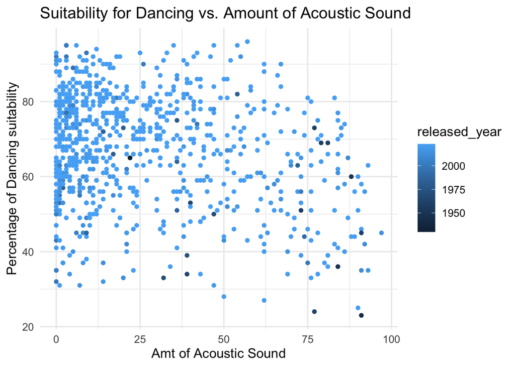

```r
music_df %>%
  ggplot(aes(x=acousticness_., y=danceability_., color=released_year)) +
  geom_point() +
  ggtitle("Suitability for Dancing vs. Amount of Acoustic Sound") +
  labs(x = "Amt of Acoustic Sound", y="Percentage of Dancing suitability")
```

When acoustic sound is compared with dancing suitability, they show a slight inverse relationship. This slight downward trend is expected, since acoustic songs are usually less upbeat and therefore not as danceable.

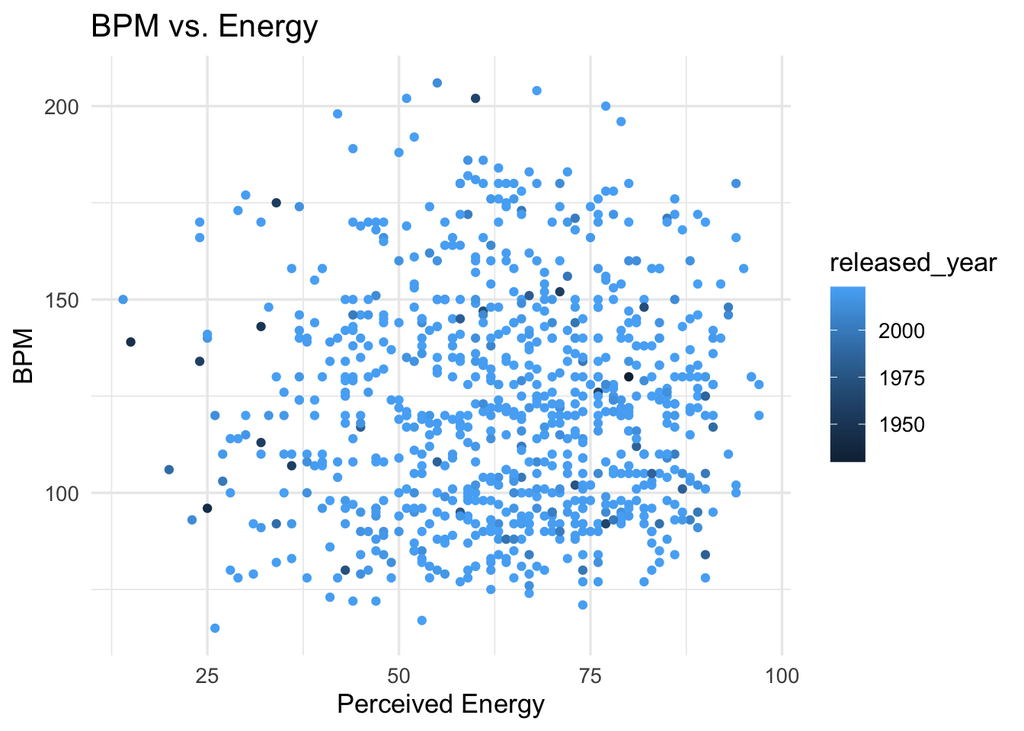

```r
music_df %>%
  ggplot(aes(x=energy_., y=bpm, color=released_year)) +
  geom_point() +
  ggtitle("BPM vs. Energy") +
  labs(x = "Perceived Energy", y="BPM")
```

This graph shows a subtle direct correlation between beats per minute and perceived energy, however, I expected the relationship to be stronger.

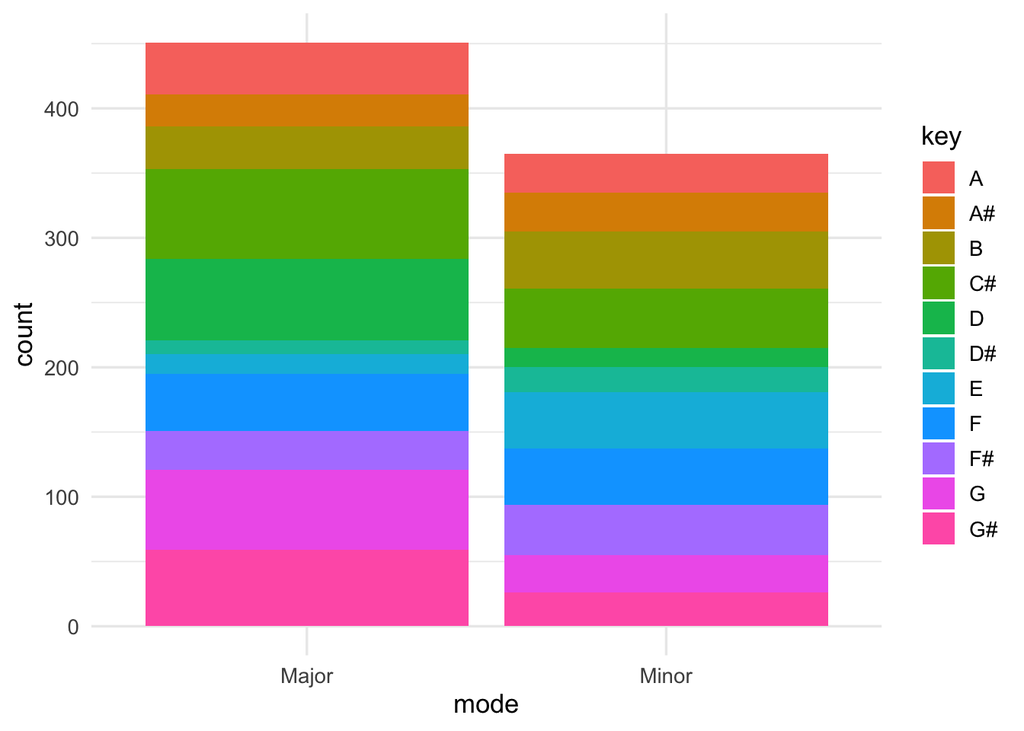

```r
music_df %>%
  ggplot(aes(x = mode, fill = key)) +
  geom_bar()
```

This graph shows that more songs were written in the a Major mode than in a Minor mode. Additionally, the coloring shows a breakdown of which keys were used in the major and minor modes. These colored sectors are difficult to compare directly because Major mode has a larger number of data points, but visually it appears that the middle of the key scale was used more frequently in songs in minor mode. On the other hand, songs written in major mode use the upper and lower extremities of the key scale most frequently.

## Models

### Regression Models

For this investigation, we will use both regression and classification modeling for different purposes. The various regression models will make predictions about the number of streams a song will receive based on the number of artists, the number of Spotify playlists it is in, the highest it has reached on Spotify’s charts, the beats per minute, the key, the mode, the danceability, the valence, the energy, the acousticness, the liveness, and the speechiness. To accomplish this, we have used a wide variety of regression techniques namely a linear regression, a K nearest neighbors, a random forest, and a boosted tree.

To perform our modeling, lets first split our data into training and tests splits and create some cross validation folds:

```r
# Create splits
set.seed(123)
music_split <- initial_split(music_df, prop = 0.80, strata = streams)
music_train <- training(music_split)
music_test <- testing(music_split)

music_folds <- vfold_cv(music_train, strata = streams)
```

To prepare our data for modeling, let’s also take some preprocessing steps.

```r
# Create a recipe
music_rec <- recipe(streams ~ artist_count + in_spotify_playlists + in_spotify_charts + bpm + key + mode + danceability_. + valence_. + energy_. + acousticness_. + liveness_. + speechiness_., data = music_df) %>%
  step_dummy(all_nominal_predictors()) %>%
  step_normalize(all_numeric_predictors()) %>%
  step_naomit()

music_rec <- prep(music_rec, training = music_train)
music_rec
```

Then, we need to create our model specifications:

```r
# Model Specifications

# Linear Regression
lr_spec <- linear_reg() %>% set_engine("lm")

# Nearest Neighbors
knn_spec <- nearest_neighbor(neighbors = tune()) %>%
  set_mode("regression") %>%
  set_engine("kknn")

# Random Forest
rf_spec <-
  rand_forest(mtry = tune(), min_n = tune(), trees = 10) %>%
  set_mode("regression") %>%
  set_engine("randomForest")

# Boosted Tree
boost_spec <- boost_tree(
  trees = 10,
  tree_depth = tune(), min_n = tune(),
  loss_reduction = tune(),
  sample_size = tune(), mtry = tune(),
  learn_rate = tune()
) %>%
  set_engine("xgboost") %>%
  set_mode("regression")
```

Now, let’s compare our models using a workflow set:

```r
music_models <-
  workflow_set(
    preproc = list(music_recipe = music_rec),
    models = list(lr = lr_spec,
                  knn = knn_spec,
                  rf = rf_spec,
                  boost = boost_spec),
    cross = TRUE
  )

music_modeling <-
  music_models %>%
  workflow_map(
    resamples = music_folds,
    metrics = metric_set(rmse),
    seed = 3,
    verbose = TRUE
  )
```

Let’s see how our models did:

```r
results <- rank_results(music_modeling) %>% head(15) %>%
  kable()
results
```

| wflow_id | .config | .metric | mean | std_err | n | preprocessor | model | rank |
| --- | --- | --- | --- | --- | --- | --- | --- | --- |
| music_recipe_rf | Preprocessor1_Model04 | rmse | 0.2541307 | 0.0116333 | 10 | recipe | rand_forest | 1 |
| music_recipe_rf | Preprocessor1_Model10 | rmse | 0.2585563 | 0.0113946 | 10 | recipe | rand_forest | 2 |
| music_recipe_rf | Preprocessor1_Model05 | rmse | 0.2586587 | 0.0130695 | 10 | recipe | rand_forest | 3 |
| music_recipe_rf | Preprocessor1_Model08 | rmse | 0.2617333 | 0.0135690 | 10 | recipe | rand_forest | 4 |
| music_recipe_rf | Preprocessor1_Model01 | rmse | 0.2649782 | 0.0124708 | 10 | recipe | rand_forest | 5 |
| music_recipe_rf | Preprocessor1_Model03 | rmse | 0.2653933 | 0.0128597 | 10 | recipe | rand_forest | 6 |
| music_recipe_rf | Preprocessor1_Model09 | rmse | 0.2716660 | 0.0114597 | 10 | recipe | rand_forest | 7 |
| music_recipe_rf | Preprocessor1_Model07 | rmse | 0.2819035 | 0.0100849 | 10 | recipe | rand_forest | 8 |
| music_recipe_rf | Preprocessor1_Model06 | rmse | 0.3098249 | 0.0154385 | 10 | recipe | rand_forest | 9 |
| music_recipe_boost | Preprocessor1_Model08 | rmse | 0.3329773 | 0.0112608 | 10 | recipe | boost_tree | 10 |
| music_recipe_rf | Preprocessor1_Model02 | rmse | 0.3448794 | 0.0144514 | 10 | recipe | rand_forest | 11 |
| music_recipe_lr | Preprocessor1_Model1 | rmse | 0.3574665 | 0.0112902 | 10 | recipe | linear_reg | 12 |
| music_recipe_knn | Preprocessor1_Model9 | rmse | 0.4105910 | 0.0142196 | 10 | recipe | nearest_neighbor | 13 |
| music_recipe_knn | Preprocessor1_Model8 | rmse | 0.4109899 | 0.0141088 | 10 | recipe | nearest_neighbor | 14 |
| music_recipe_knn | Preprocessor1_Model7 | rmse | 0.4116457 | 0.0139346 | 10 | recipe | nearest_neighbor | 15 |

#### Results

The random forest model is performing the best, so we will fit that as our final model.

```r
extract_workflow_set_result(music_modeling, "music_recipe_rf") %>%
  unnest(.metrics) %>%
  glimpse()

rf_workflow <- music_modeling %>%
  extract_workflow("music_recipe_rf")

rf_workflow_fit <-
  rf_workflow %>%
  finalize_workflow(tibble(mtry = 8, min_n = 25))

rf_fit <- last_fit(rf_workflow_fit, music_split)
```

```r
collect_metrics(rf_fit) %>%
  kable()
```

| .metric | .estimator | .estimate | .config |
| --- | --- | --- | --- |
| rmse | standard | 0.4490392 | Preprocessor1_Model1 |
| rsq | standard | 0.4231846 | Preprocessor1_Model1 |

Finally, let’s examine which predictors contribute most to our model’s prediction:

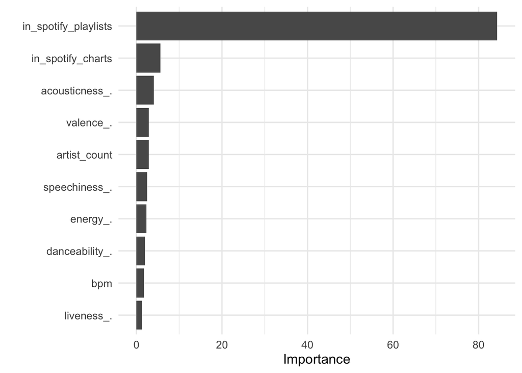

```r
extract_workflow(rf_fit) %>%
  extract_fit_parsnip() %>%
  vip()
```

Based on this visualization, the number of Spotify playlists contributed most significantly to the model prediction by a large margin. The audio features which most significantly contribute are acousticness (amount of acoustic sound in the song) and valence (positivity of the song’s musical content).

Since we know which variables affect the number of streams the most, let’s see how they are correlated.

```
Correlations:
```

```
# of Spotify Playlists and # of Streams:
```

```
0.6132324
```

```
Amount of Acoustic Sound and # of Streams:
```

```
-0.02956645
```

```
Positivity of Musical Content and # of Streams:
```

```
-0.05491919
```

As shown above, # of Spotify Playlists and # of Streams have a positive correlation, indicating that the more playlists a song is in, the higher the number of streams will be. On the other hand, the Amount of Acoustic Sound and Positivity of Musical Content have an inverse relationship with # of Streams meaning the lower each other those values, the higher the number of streams will be.

### Classification Model

First, let’s determine which artists have appeared on the charts the most often.

```r
music_df %>%
  group_by(artist.s._name) %>%
  summarise(
    n = n(),
    in_spotify_charts = median(in_spotify_charts)
  ) %>%
  arrange(-n)
```

```
# A tibble: 570 × 3
   artist.s._name       n in_spotify_charts
   <chr>            <int>             <dbl>
 1 Taylor Swift        29                12
 2 SZA                 17                 0
 3 Bad Bunny           16                 3
 4 The Weeknd          15                 0
 5 Harry Styles        12                 1
 6 Kendrick Lamar      12                 0
 7 Morgan Wallen        9                 4
 8 Feid                 8                21
 9 BTS                  7                 0
10 Drake, 21 Savage     7                 0
# ℹ 560 more rows
```

Taylor Swift, SZA, and Bad Bunny are the top 3 artists with the most appearances on the Spotify charts in 2023.

Now, we will split our data, transforming the numerical “in_spotify_charts” variable to a binary categorical variable with the values “Top 10” and “Below”.

```r
set.seed(123)
class_split <-
  music_df %>%
  transmute(
    artist.s._name,
    in_spotify_charts = if_else(in_spotify_charts < 10, "Top 10", "Below")
  ) %>%
  na.omit() %>%
  initial_split(strata = in_spotify_charts)

class_train <- training(class_split)
class_test <- testing(class_split)

set.seed(234)
class_folds <- vfold_cv(class_train, strata = in_spotify_charts)
```

```r
# Linear SVM
svm_spec <- svm_linear(mode = "classification")

class_rec <-
recipe(in_spotify_charts ~ artist.s._name, data = music_train) %>%
  step_tokenize(artist.s._name) %>%
  step_tf(artist.s._name) %>%
  step_normalize(all_numeric_predictors())

svm_wf <- workflow(class_rec, svm_spec)

doParallel::registerDoParallel()

set.seed(123)
svm_metrics <- metric_set(accuracy, sens, spec)

svm_rs <- fit_resamples(svm_wf, resamples = class_folds, metrics = svm_metrics)

final_svm <- last_fit(svm_wf, class_split, metrics = svm_metrics)
```

#### Results

Let’s see how we did:

```r
collect_metrics(final_svm) %>%
  kable()
```

| .metric | .estimator | .estimate | .config |
| --- | --- | --- | --- |
| accuracy | binary | 0.6715686 | Preprocessor1_Model1 |
| sens | binary | 0.4492754 | Preprocessor1_Model1 |
| spec | binary | 0.7851852 | Preprocessor1_Model1 |

Our model has an accuracy, sensitivity and specificity rates of approximately 67%, 45%, and 79%, respectively.

Below is the corresponding confusion matrix. The main diagonal of a confusion matrix represents correctly predicted samples. The visualization shows that, more often than not, our model is able to correctly classify songs as having been in the top 10. As shown by the left side of the matrix, our model has a more difficult time correctly classifying songs that lie outside of the top 10, but generally performs well overall.

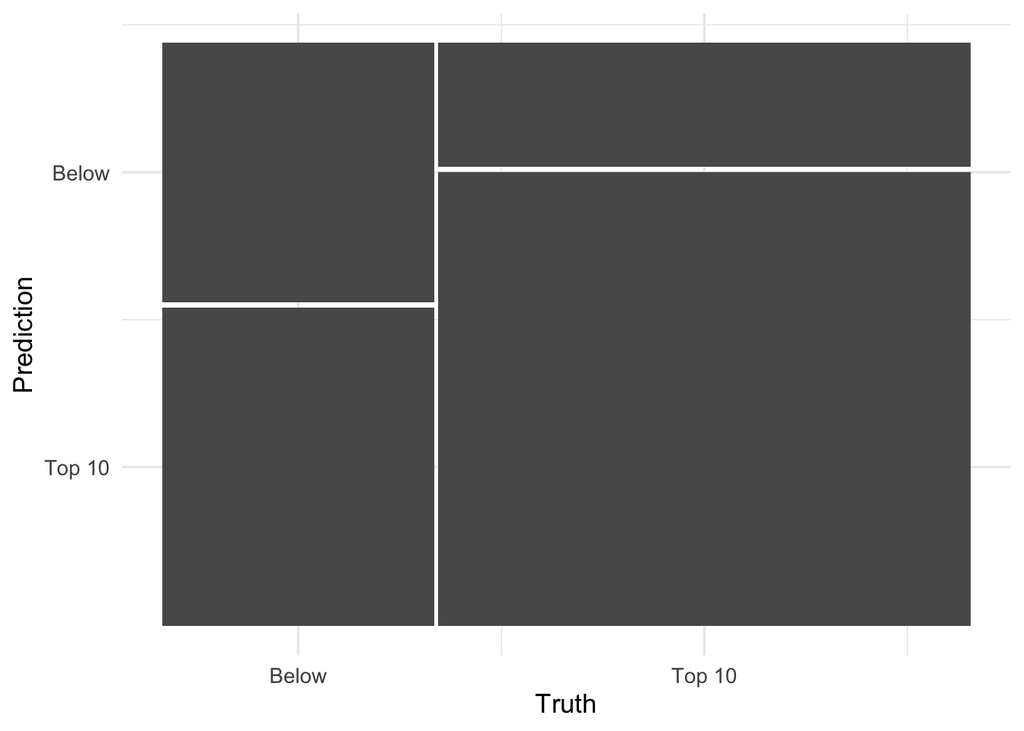

```r
collect_predictions(final_svm) %>%
  conf_mat(in_spotify_charts, .pred_class) %>%
  autoplot()
```

Finally, lets take a look at which parts of artists’ names have the greatest impact on classification.

```r
final_fited <- extract_workflow(final_svm)

tidy(final_fited) %>%
  slice_max(abs(estimate), n = 20) %>%
  kable()
```

| term | estimate |
| --- | --- |
| Bias | -0.3345498 |
| tf_artist.s._name_boomin | 0.1949015 |
| tf_artist.s._name_metro | 0.1949015 |
| tf_artist.s._name_anitta | -0.1826349 |
| tf_artist.s._name_bizarrap | 0.1734524 |
| tf_artist.s._name_blake | -0.1728683 |
| tf_artist.s._name_quevedo | 0.1553310 |
| tf_artist.s._name_eminem | 0.1550832 |
| tf_artist.s._name_hope | -0.1419025 |
| tf_artist.s._name_cole | 0.1415682 |
| tf_artist.s._name_frontera | 0.1414028 |
| tf_artist.s._name_tini | 0.1412532 |
| tf_artist.s._name_feid | 0.1319382 |
| tf_artist.s._name_future | -0.1238119 |
| tf_artist.s._name_halsey | -0.1166573 |
| tf_artist.s._name_arthur | 0.1154653 |
| tf_artist.s._name_travis | -0.1152857 |
| tf_artist.s._name_jimin | 0.1101665 |
| tf_artist.s._name_coi | -0.0995613 |
| tf_artist.s._name_leray | -0.0995613 |

A positive estimate value indicates an increased likelihood that the artist will be in the top 10 and a negative value suggests the opposite. From this, we can determine that if the artist’s name contains “Boomin” or “Metro,” the song is more likely to be predicted to be in the top 10, whereas if the artist’s name contains “Anitta,” that song is less likely to be predicted in the top 10, and so on.

## Conclusions

In this report, we have analyzed the relationships between the number of streams a song will receive and its various characteristics. From this investigation we found that the number of Spotify playlists a song is in has the greatest overall impact on the number of streams it will receive. This aligns with what we would expect to be this case. If a song is in a high number of playlists, it follows that the song would be played more often and vice versa. Regarding the auditory characteristics of the song, the acousticness and valence had the greatest impact on the number of streams. If there is a lower acousticness, there will be more streams. Similarly, if there is lower valence, there will be a higher number of streams.

Although these predictors have the greatest impact on predicting streams, there are also many other factors that result in song popularity such as marketing tactics, having a pre-established fanbase, music trends, etc. Because of this, it is not necessarily the case that having a song with lower acousticness or valence will automatically result in a more popular song. However, at least during 2023, songs with these qualities received the most streams, so it is possible that a similar song would also be well received.

The implementation of the classification model provided insights into which artists were most popular in 2023, and how the artists that contribute to a song might affect the song’s popularity. For example, we were able to determine that artists like Metro Boomin, Bizarrap, and Eminem, have a higher likelihood of being in the top 10 than Future or Halsey. Again, there are a lot of factors that go into a song’s popularity so it is not guaranteed that these artists’ songs will have the best performance every time. However, this information could be used to devise collaborations between artists and potentially result in a better performing song.

## References

Elgiriyewithana, Nidula. “Most Streamed Spotify Songs 2023.” Kaggle, Kaggle, https://www.kaggle.com/datasets/nelgiriyewithana/top-spotify-songs-2023.

Silge, Julia. “Evaluating multiple modeling approaches for #TidyTuesday spam email.” JuliaSilge, Julia Silge, 1 Sept. 2023, https://juliasilge.com/blog/spam-email/.

Silge, Julia. “Predict #TidyTuesday NYT bestsellers” JuliaSilge, Julia Silge, 11 May 2022, https://juliasilge.com/blog/nyt-bestsellers/.